# EDA

Lukáš Častven, Michal Kilian

2025-04-29

# Predicting LoL game winner

League of Legends (LoL) is a 5v5 multiplayer online battle arena (MOBA) game. Teams compete to destroy the enemy’s base structure, the Nexus.

Our project goal is to predict the winning team based on events occurring within the first `N` minutes of professional matches.

## Dataset

The dataset consists of three CSV files: `game_metadata.csv`, `game_players_stats.csv`, and `game_events.csv`. The fields `game_id` and `player_id` link these files. Additionally we found dataset `260225_LoL_champion_data.csv` containing metadata about champions, which can be linked by the champion name.

### Source

The dataset contains detailed statistics and events from professional LoL matches (2019-2024). It was published on [IEEE DataPort under a CC license](https://ieee-dataport.org/documents/league-legends-esports-player-game-data-2019-2024). However, since IEEE is a greedy corporation, accessing it there requires a paid subscription.

We obtained the identical dataset directly from the authors’ GitHub repository (PandaScore/PandaSkill). This source provides the data under the permissive MIT license.

The dataset containing metadata about champions up to February 2025, can be found on Kaggle under name [25.S1.4 League of Legends Champion Data (2025)](https://www.kaggle.com/datasets/laurenainsleyhaines/25-s1-4-league-of-legends-champion-data-2025/data). The original dataset didn’t include champion classifications like ‘Fighter’, ’Mage, and we think it might help.

### `game_metadata.csv`

This file contains general information about each game.

- `game_id`: Unique game identifier.
- `date`: Game date and time in format YYYY-MM-DD HH:MM:SS.ssssss.
- `match_id`: Identifier for the match (e.g., a best-of-5 series).
- `tournament_id`: Unique tournament identifier.
- `tournament_name`: Name of the tournament.
- `series_id`: Unique series identifier.
- `series_name`: Name of the series (e.g., LCK Summer 2024).
- `league_id`: Unique league identifier.
- `league_name`: Name of the league (e.g., LCK).
- *Note:* Games belong to matches, matches to tournaments, tournaments to series, and series to leagues.

### `game_players_stats.csv`

This file provides player statistics at the end of each game.

- `game_id`: Unique game identifier.
- `player_id`: Unique player identifier.
- `player_name`: Player’s in-game name.
- `team_id`: Unique team identifier.
- `team_name`: Name of the player’s team.
- `team_acronym`: Team’s acronym.
- `role`: Player’s role (e.g., Mid).
- `win`: Binary indicator (1 if player won, 0 otherwise).
- `game_length`: Duration of the game in seconds.
- `champion_name`: Name of the champion played.
- `team_kills`: Total champion kills by the player’s team.
- `tower_kills`: Total tower kills by the player’s team.
- `inhibitor_kills`: Total inhibitor kills by the player’s team.
- `dragon_kills`: Total dragon kills by the player’s team.
- `herald_kills`: Total Rift Herald kills by the player’s team.
- `baron_kills`: Total Baron Nashor kills by the player’s team.
- `player_kills`: Player’s champion kills.
- `player_deaths`: Player’s deaths.
- `player_assists`: Player’s assists.
- `total_minions_killed`: Player’s minion kills (CS).
- `gold_earned`: Player’s total gold earned.
- `level`: Player’s final champion level.
- `total_damage_dealt`: Player’s total damage dealt.
- `total_damage_dealt_to_champions`: Player’s damage dealt to enemy champions.
- `total_damage_taken`: Player’s total damage taken.
- `wards_placed`: Player’s number of wards placed.
- `largest_killing_spree`: Player’s largest killing spree count.
- `largest_multi_kill`: Player’s largest multi-kill count (e.g., 2 for double kill).

### `game_events.csv`

This file contains specific events occurring during each game.

- `game_id`: Unique game identifier.
- `timestamp`: Time in seconds when the event occurred.
- `event_type`: Type of event (e.g., `player_kill`, `drake_kill`).
- `killer_id`: ID of the player who got the kill (if applicable).
- `killed_id`: ID of the player/unit killed (if applicable).
- `assisting_player_ids`: List of IDs of assisting players (for kills).
- `drake_type`: Type of dragon killed (e.g., infernal, cloud).

### `260225_LoL_champion_data.csv`

This file contains metadata about champions up to February 2025, we only want the name and it’s type.

- `first column`: Name of the champion.
- `herotype`: What type is the champion.

## Hypothesis

We hypothesize that if a team has more advantages in early game (events that happen before `N`th minute), then they are more likely to win the whole game. We want to classify, based on early games state, if team 1 will win or loose.

## Representing early game state

We will create features representing the relative advantage between the two teams at the `N` minute. This involves calculating the difference in key objectives (kills, dragons, heralds, towers) and identifying which team secured the first significant event (first blood, first dragon, first herald) with timestamps of these events. Also We will calculate differences in champion types for each team.

### Steps

1. Filter raw player statistics to select games with complete data (10 players, 2 distinct teams).
2. Identify `team1_id` (numerically lower ID) and `team2_id` (numerically higher ID) for each valid game.
3. Create the target variable `team1_won` (1 if team 1 won, 0 otherwise) based on player win status.
4. Build a lookup table mapping `player_id` to `team_id` within each game.
5. Filter raw game events to include only those occurring before the specified cutoff time.
6. Select relevant event types: `player_kill`, `drake_kill`, `rift_herald_kill`, `tower_kill`.
7. Count the occurrences of these selected event types for team1 and team2 in each game, filling missing counts with 0.
8. Calculate difference features (`_diff`) by subtracting team 2’s event counts from team 1’s counts (e.g., `kill_diff = player_kill_team1 - player_kill_team2`). Replace potential NA values with 0.
9. Identify the first occurrence for kills (blood), dragons, heralds, and towers before the cutoff time.
10. Determine which team (`team1`, `team2`, or `none`) secured each first event. Assign `none` if no event occurred or if events were simultaneous (tied timestamp). Record the timestamp (`time_first_*`) for each first event.
11. Join player stats with champion role/type data.
12. Count the number of champions of each type (Fighter, Mage, etc.) for team1 and team2 in each game, filling missing counts with 0.
13. Calculate champion type difference features (`_champdiff`) by subtracting team 2’s champion type counts from team 1’s counts.
14. Combine `game_id`, team IDs, `team1_won`, all `_diff` features, all `first_` features, all `time_first_*` features, and all `_champdiff` features into the final dataset structure.
15. Convert `first_` features (e.g., `first_blood`) to factors, replacing any NA values with the level `none`.

### Resulting dataset structure

The final dataset will have one row per `game_id`. Each row represents the state of a game after `N` minutes, along with the final outcome. Columns will include:

- `game_id`: Unique game identifier.
- `team1_id`: Unique identifier for team 1 (arbitrarily assigned as the lower ID).
- `team2_id`: Unique identifier for team 2 (arbitrarily assigned as the higher ID).
- `team1_won`: Numeric target variable (1 if team 1 won, 0 otherwise).
- `kill_diff`: Numeric difference (team 1 kills - team 2 kills) at `N` minutes.
- `dragon_diff`: Numeric difference (team 1 dragons - team 2 dragons) at `N` minutes.
- `rift_herald_diff`: Numeric difference (team 1 heralds - team 2 heralds) at `N` minutes.
- `tower_diff`: Numeric difference (team 1 towers - team 2 towers) at `N` minutes.
- `first_blood`: Factor indicating which team got the first kill (‘team1’, ‘team2’, ‘none’ if tied or no kill before `N min).
- `time_first_blood`: Numeric time (in seconds) when the first blood occurred (NA if none before `N` min or tied).
- `first_dragon`: Factor indicating which team got the first dragon (‘team1’, ‘team2’, ‘none’ if tied or no dragon before N min).
- `time_first_dragon`: Numeric time (in seconds) when the first dragon occurred (NA if none before `N` min or tied).
- `first_herald`: Factor indicating which team got the first herald (‘team1’, ‘team2’, ‘none’ if tied or no herald before `N` min).
- `time_first_herald`: Numeric time (in seconds) when the first herald occurred (NA if none before `N` min or tied).
- `first_tower`: Factor indicating which team got the first tower (‘team1’, ‘team2’, ‘none’ if tied or no tower before N min).
- `time_first_tower`: Numeric time (in seconds) when the first tower occurred (NA if none before `N` min or tied).
- `fighter_champdiff`: Numeric difference (team 1 fighters - team 2 fighters).
- `mage_champdiff`: Numeric difference (team 1 mages - team 2 mages).
- `assassin_champdiff`: Numeric difference (team 1 assassins - team 2 assassins).
- `marksman_champdiff`: Numeric difference (team 1 marksmen - team 2 marksmen).
- `tank_champdiff`: Numeric difference (team 1 tanks - team 2 tanks).
- `support_champdiff`: Numeric difference (team 1 supports - team 2 supports).

```r
N <- 12 * 60
dataset <- early_game_dataset(player_stats, metadata, events, champs, N)
```

This gives us a dataset containing 37449 early game states. With that many matches, we’re confident we have large enough dataset. So, we decided to skip doing a formal power analysis because the sheer amount of data should be more than enough.

The choice of `N = 12 minutes` is arbitrary, just from our experience of playing LoL. The definition of “early game” is: The game phase where players focus on their lanes, and it ends when the first turret in any lane is destroyed. [source](https://gameboost.com/definitions/league-of-legends/early-game) As can be seen later in EDA, 10 to 12 minutes have the most first towers destroyed.

## Notice on LLM usage

We utilized LLMs for assistance with refining plot styling and brainstorming visualization ideas presented in this EDA.

## EDA

### Target `team1_won`

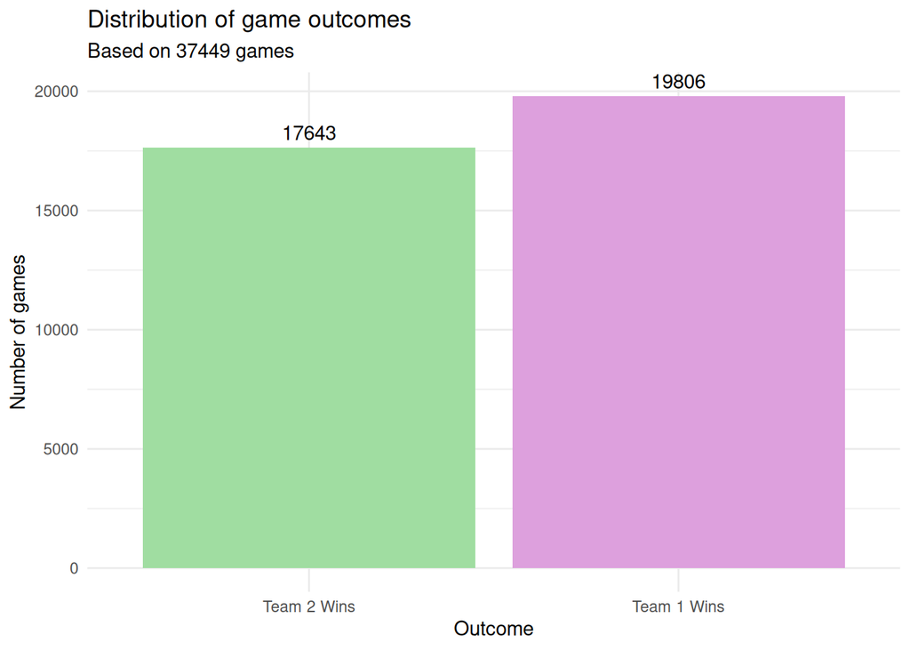

```r
ggplot(dataset, aes(x = factor(team1_won))) +
    geom_bar(aes(y = after_stat(count)), fill = c(color2, color1)) +
    geom_text(
        aes(y = after_stat(count), label = after_stat(count)),
        stat = "count",
        vjust = -0.5
    ) +
    scale_x_discrete(labels = c("0" = "Team 2 Wins", "1" = "Team 1 Wins")) +
    labs(
        title = "Distribution of game outcomes",
        subtitle = paste("Based on", nrow(dataset), "games"),
        x = "Outcome",
        y = "Number of games"
    ) +
    theme_minimal()
```

The dataset appears reasonably balanced between team 1 and team 2 wins. Around 47% to 53%. The difference is caused by team 1 being the blue side, which has an advantage in picking champions before the game, that we can’t address.

### Event `_diff` features

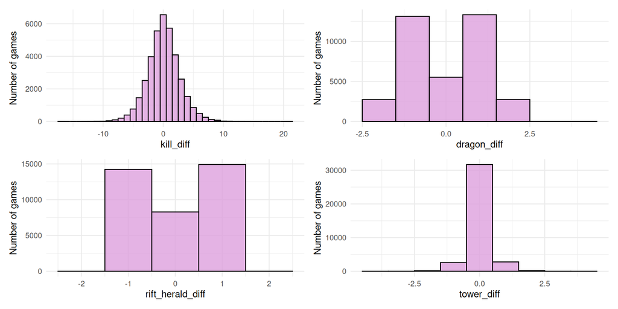

```r
dataset %>%
    select(ends_with("_diff")) %>%
    colnames() %>%
    map(~ {
        col_sym <- sym(.x)
        ggplot(dataset, aes(x = !!col_sym)) +
            geom_histogram(
                binwidth = 1,
                center = 0,
                fill = color1,
                color = "black",
                alpha = 0.8
            ) +
            labs(x = .x, y = "Number of games") +
            theme_minimal()
    }) %>%
    wrap_plots(ncol = 2)
```

The distribution of `kill_diff` seem promising. Just from looking at it, it appears like a normal distribution. `dragon_diff` suggests that either there are no diffs, or one team dominates in this metric. And since rift herald spawns later and is more difficult to kill, thus the diff is only 1 (-1), there aren’t many kills of it in early game. In many games there is no `tower_diff`.

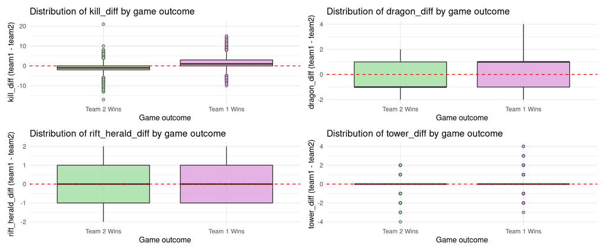

```r
dataset %>%
    select(ends_with("_diff")) %>%
    colnames() %>%
    map(~ {
        col_sym <- sym(.x)

        dataset %>%
            ggplot(aes(x = factor(team1_won), y = !!col_sym, fill = factor(team1_won))) +
            geom_boxplot(alpha = 0.8, outlier.shape = 21, outlier.size = 1.5) +
            scale_x_discrete(labels = c("0" = "Team 2 Wins", "1" = "Team 1 Wins")) +
            scale_fill_manual(
                values = c("0" = color2, "1" = color1),
                guide = "none"
            ) +
            geom_hline(yintercept = 0, linetype = "dashed", color = "red", linewidth = 0.5) +
            labs(
                title = paste("Distribution of", .x, "by game outcome"),
                x = "Game outcome",
                y = paste(.x, "(team1 - team2)")
            ) +
            theme_minimal()
    }) %>%
    wrap_plots(ncol = 2)
```

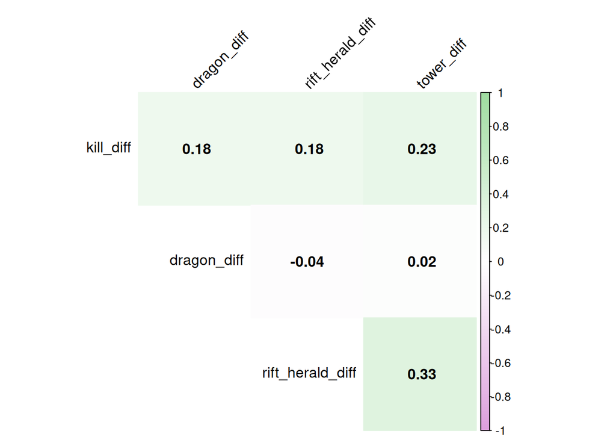

```r
custom_palette <- colorRampPalette(c(color1, "white", color2))(100)

dataset %>%
    select(ends_with("_diff")) %>%
    cor(use = "pairwise.complete.obs") %>%
    corrplot(
        method = "color",
        col = custom_palette,
        type = "upper",
        tl.col = "black",
        tl.srt = 45,
        addCoef.col = "black",
        number.cex = 1,
        diag = F,
        mar = c(0, 0, 1, 0))
```

The correlation matrix seems promising, no strong correlation between `_diff` features.

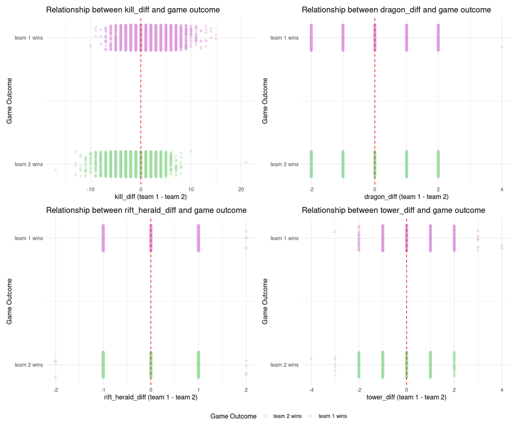

```r
dataset %>%
    select(ends_with("_diff")) %>%
    colnames() %>%
    map(~ {
        col_sym = sym(.x)

        dataset %>%
            ggplot(aes(x = !!col_sym, y = team1_won)) +
            geom_jitter(
                aes(color = factor(team1_won)),
                width = 0,
                height = 0.1,
                alpha = 0.3,
                size = 1.5) +
            scale_color_manual(
                values = c("0" = color2, "1" = color1),
                labels = c("0" = "team 2 wins", "1" = "team 1 wins"),
                name = "Game Outcome") +
            scale_y_continuous(
                breaks = c(0, 1),
                labels = c("0" = "team 2 wins", "1" = "team 1 wins")) +
            labs(
                title = paste("Relationship between", .x, "and game outcome"),
                x = paste(.x, "(team 1 - team 2)"),
                y = "Game Outcome") +
            theme_minimal() +
            theme(legend.position = "bottom") +
            geom_vline(xintercept = 0, linetype = "dashed", color = "red", linewidth = 0.5)
    }) %>%
    wrap_plots(ncol = 2, guides = "collect") &
    theme(legend.position = "bottom")
```

But `_diff` features alone are not enough to predict outcome of a game. Only `kill_diff` shows some separation but still there is big overlap. Using them with logistic regression would produce a model with a lot of errors.

### Team compositions diffs

Champions can put in classes like `tank`, `fighter`, `mage` and so on. If there is an difference in champion types, then maybe there can is some relation to the win rate of games.

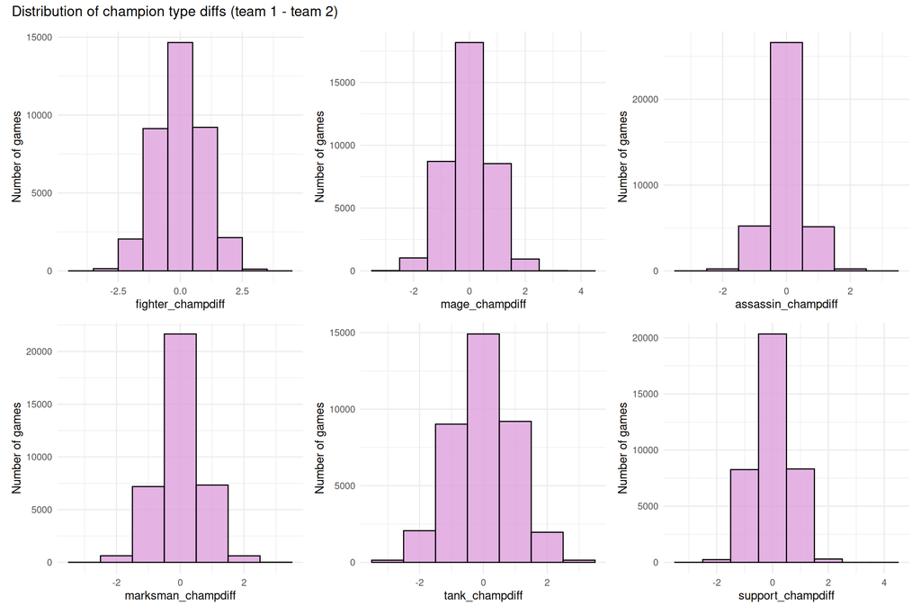

```r
dataset %>%
    select(ends_with("_champdiff")) %>%
    colnames() %>%
    map(~ {
        col_sym <- sym(.x)

        dataset %>%
            ggplot(aes(x = !!col_sym)) +
            geom_histogram(
                binwidth = 1,
                center = 0,
                fill = color1,
                color = "black",
                alpha = 0.8) +
            labs(x = .x, y = "Number of games") +
            theme_minimal()}) %>%
    wrap_plots(ncol = 3) +
    plot_annotation(title = "Distribution of champion type diffs (team 1 - team 2)")
```

Well, in all types, the most dominant difference is 0. This makes sense because during some LoL meta, teams tend to play the same things, so the teams have similiar team compositions.

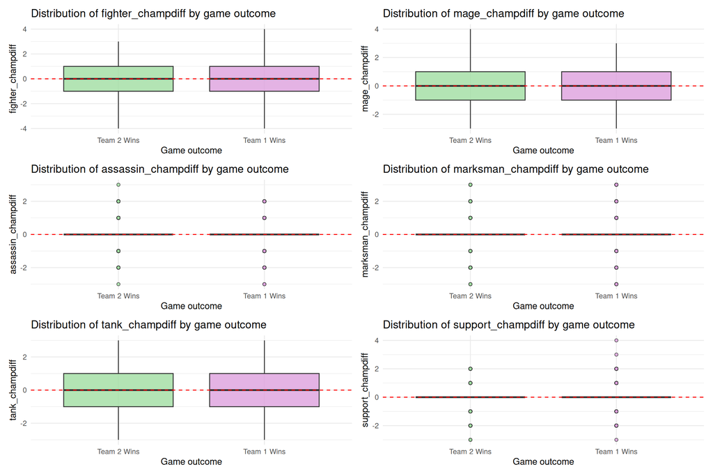

```r
dataset %>%
    select(ends_with("_champdiff")) %>%
    colnames() %>%
    map(~ {
        col_sym <- sym(.x)

        dataset %>%
            ggplot(aes(x = factor(team1_won), y = !!col_sym, fill = factor(team1_won))) +
            geom_boxplot(alpha = 0.8, outlier.shape = 21, outlier.size = 1.5) +
            scale_x_discrete(labels = c("0" = "Team 2 Wins", "1" = "Team 1 Wins")) +
            scale_fill_manual(
                values = c("0" = color2, "1" = color1),
                guide = "none"
            ) +
            geom_hline(yintercept = 0, linetype = "dashed", color = "red", linewidth = 0.5) +
            labs(
                title = paste("Distribution of", .x, "by game outcome"),
                x = "Game outcome",
                y = .x
            ) +
            theme_minimal()
    }) %>%
    wrap_plots(ncol = 2)
```

Distributions of champion diffs don’t suggest anything useful. Boxplots show minimal separation between winning and losing outcomes based on champion class differences. We won’t be exploring these features as we think the analysis up this point proves they are not relevant.

### `first_` features

#### Distributions

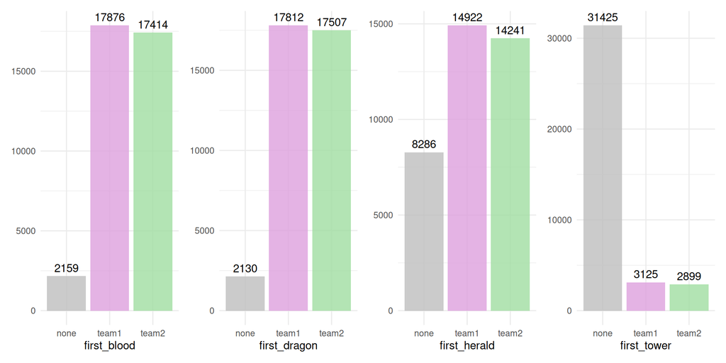

```r
dataset %>%
    select(starts_with("first_")) %>%
    colnames() %>%
    map(~ {
        col_sym <- sym(.x)

        dataset %>%
            ggplot(aes(x = !!col_sym)) +
            geom_bar(aes(fill = !!col_sym), stat = "count", alpha = 0.8) +
            geom_text(
                aes(label = after_stat(count)),
                stat = "count",
                vjust = -0.5
            ) +
            scale_fill_manual(
                values = c("team1" = color1, "team2" = color2, "none" = "grey"),
                guide = "none") +
            labs(y = NULL) +
            theme_minimal()
    }) %>%
    wrap_plots(ncol = 4)
```

If an `first_` event occurred in the early game, then it is around 50/50 split between team 1 and team 2 achieving it. `first_tower` didn’t happen in 84% of games.

#### Securing `first_` event and winning a game

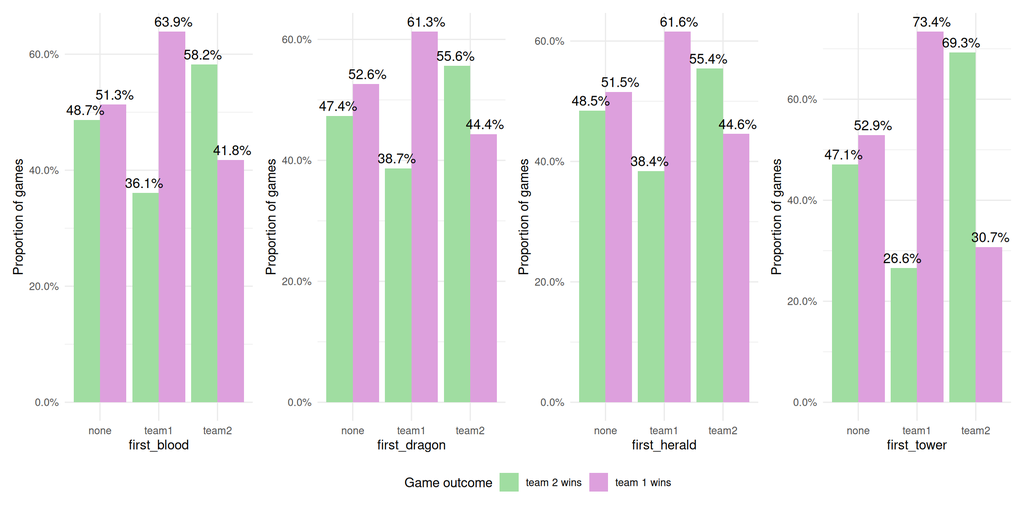

```r
# inspired by https://rpubs.com/stephenmoore56/345708 and
# https://stackoverflow.com/questions/48086575/ggplot2-problems-with-using-prop-and-grouping-bar-graph-by-another-categor
dataset %>%
    select(starts_with("first_")) %>%
    colnames() %>%
    map(~ {
        col_sym <- sym(.x)

        dataset %>%
            mutate(team1_won = factor(
                team1_won,
                levels = c(0, 1),
                labels = c("team 2 wins", "team 1 wins")
            )) %>%
            count(!!col_sym, team1_won, name = "n") %>%
            group_by(!!col_sym) %>%
            mutate(prop = n / sum(n)) %>%
            ungroup() %>%
            ggplot(aes(x = !!col_sym, y = prop, fill = team1_won)) +
            geom_col(position = position_dodge(preserve = "single")) +
            geom_text(
                aes(label = percent(prop, accuracy = .1)),
                position = position_dodge(width = 1),
                vjust = -0.5,
                size = 4) +
            scale_y_continuous(labels = percent_format(accuracy = .1)) +
            scale_fill_manual(values = c("team 1 wins" = color1, "team 2 wins" = color2)) +
            labs(y = "Proportion of games", fill = "Game outcome") +
            theme_minimal()
    }) %>%
    wrap_plots(ncol = 4, guides = "collect") &
    theme(legend.position = "bottom")
```

If a team secured a `first_` event, it won in a majority of games. However the difference between securing the event and winning the game per team are not balanced. If a team 1 secured `first_blood`, in 63.9% games it won, but if if team 2 secured it, they won only in 58.2% games. Same goes for other `first_` features. It has to do with the fact that team 1 is on the blue side, and has an advantage in picking champions before the game that we can’t address. The `first_tower` has the highest value, if a team 1 secured it they won in 73.4% games and team 2 in 69.3% of games. But `first_tower` happened only in 16% of games.

#### Timings of `first_` features

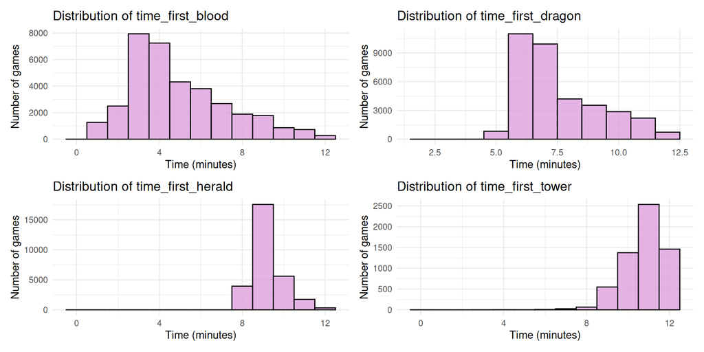

```r
dataset %>%
    select(starts_with("time_first_")) %>%
    colnames() %>%
    map(~ {
        col_sym <- sym(.x)

        dataset %>%
            filter(!is.na(!!col_sym)) %>%
            select(!!col_sym) %>%
            ggplot(aes(x = !!col_sym / 60)) +
            geom_histogram(binwidth = 1, fill = color1, color = "black", alpha = 0.8) +
            labs(
                title = paste("Distribution of", .x),
                x = "Time (minutes)",
                y = "Number of games") +
            theme_minimal()
    }) %>%
    wrap_plots(ncol = 2)
```

These graphs only reflect known timings of the game, which is a good sanity check.

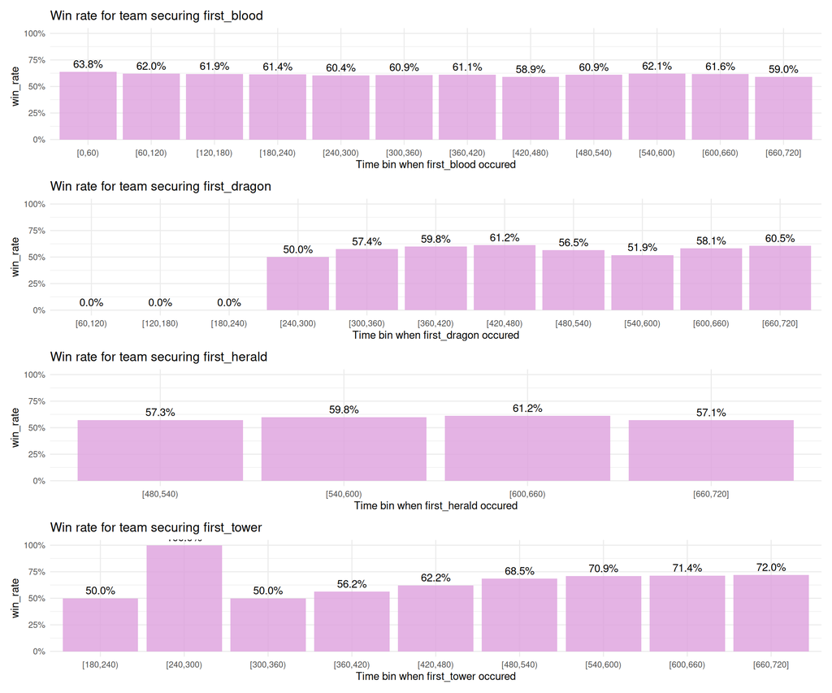

```r
first_to_times <- list(
    first_blood = "time_first_blood",
    first_dragon = "time_first_dragon",
    first_herald = "time_first_herald",
    first_tower = "time_first_tower")

first_to_times %>%
    imap(~ {
        first_col_sym <- sym(.y)
        time_col_sym <- sym(.x)

        dataset %>%
            filter(!!first_col_sym != "none") %>%
            mutate(
                time_bin = cut(
                    !!time_col_sym,
                    breaks = seq(0, N, by = 60),
                    include.lowest = TRUE,
                    right = FALSE),
                first_team_won = case_when(
                    !!first_col_sym == "team1" & team1_won == 1 ~ TRUE,
                    !!first_col_sym == "team2" & team1_won == 0 ~ TRUE,
                    TRUE ~ FALSE)) %>%
            group_by(time_bin) %>%
            summarise(
                n_games = n(),
                win_rate = mean(first_team_won, na.rm = TRUE)) %>%
            filter(!is.na(time_bin)) %>%
            ggplot(aes(x = time_bin, y = win_rate)) +
            geom_col(fill = color1, alpha = 0.8) +
            geom_text(aes(label = percent(win_rate, accuracy = 0.1)), vjust = -0.5) +
            scale_y_continuous(labels = percent_format(), limits = c(0, 1)) +
            labs(
                title = paste("Win rate for team securing", .y),
                x = paste("Time bin when", .y, "occured"),
            ) +
            theme_minimal()
    }) %>%
    wrap_plots(ncol = 1)
```

#### Relationship between the `first_` features

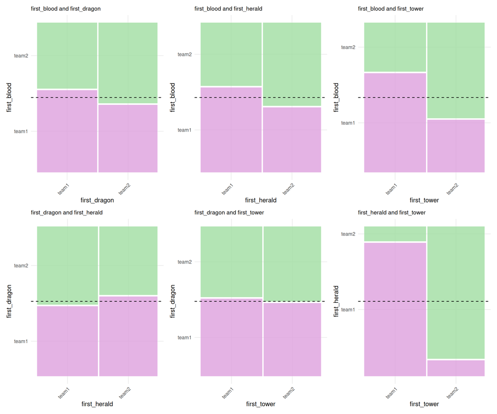

```r
# inspired by https://haleyjeppson.github.io/ggmosaic/
dataset %>%
    select(starts_with("first_")) %>%
    colnames() %>%
    combn(2, simplify = F) %>%
    map(~ {
        var1 <- .x[1]
        var2 <- .x[2]
        sym1 <- sym(var1)
        sym2 <- sym(var2)

        dataset %>%
            filter(!!sym1 != "none", !!sym2 != "none") %>%
            # removes none from axis
            mutate(
                !!var1 := factor(!!sym1, levels = c("team1", "team2")),
                !!var2 := factor(!!sym2, levels = c("team1", "team2"))) %>%
            ggplot() +
            geom_mosaic(
                aes(x = product(!!sym1, !!sym2), fill = !!sym1),
                alpha = 0.8,
                color = "white") +
            geom_hline(yintercept = 0.5, linetype = "dashed", color = "black", linewidth = 0.5) +
            scale_fill_manual(
                values = c("team1" = color1, "team2" = color2),
                guide = "none") +
            labs(title = paste(var1, "and", var2)) +
            theme_minimal() +
            theme(
                plot.title = element_text(size = 10),
                axis.text.x = element_text(angle = 45, hjust = 1)
            )
    }) %>%
    wrap_plots(ncol = 3)
```

### Relationships between `first_`s and `_diff`s

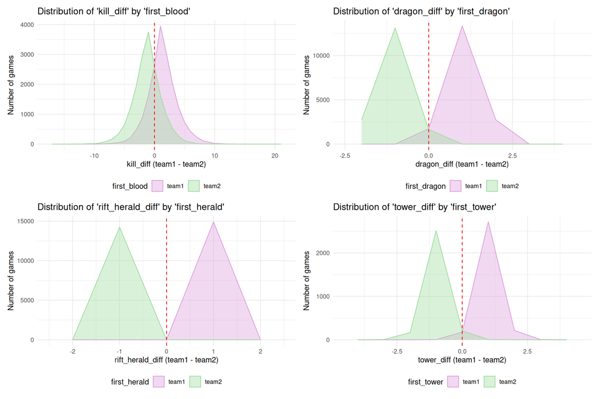

```r
direct_rels <- list(
    first_blood = "kill_diff",
    first_dragon = "dragon_diff",
    first_herald = "rift_herald_diff",
    first_tower = "tower_diff")

direct_rels  %>%
    imap(~ {
        first_col_sym <- sym(.y)
        diff_col_sym <- sym(.x)

        dataset %>%
            filter(!!first_col_sym != "none") %>%
            ggplot(aes(x = !!diff_col_sym, fill = !!first_col_sym, color = !!first_col_sym)) +
            geom_area(
                stat = "bin",
                binwidth = 1,
                position = "identity",
                alpha = 0.4) +
            scale_fill_manual(
                values = c("team1" = color1, "team2" = color2),
                name = .y) +
            scale_color_manual(
                values = c("team1" = color1, "team2" = color2),
                name = .y) +
            labs(
                title = paste0("Distribution of '", .x, "' by '", .y, "'"),
                x = paste(.x, "(team1 - team2)"),
                y = "Number of games") +
            geom_vline(xintercept = 0, linetype = "dashed", color = "red", linewidth = 0.5) +
            theme_minimal() +
            theme(legend.position = "bottom")
    }) %>%
    wrap_plots(ncol = 2)
```

From these graphs we can see that if a team secured `first_` event, then it was leading at the end of the early game in a `_diff` of that event. But all except `kill_diff` have small ranges, only the `kill_diff` has bigger value range, but there is big overlap between distributions of it.

#### Influence of `first_` on win rate with respect to `_diff`

At the end of the early game, `_diff` features can be in 3 states:

1. **0** - no team has lead in this event diff
2. **> 0** - team 1 has lead
3. **< 0** - team 2 has lead

Following graphs show what advantage (or disadvantage) achieving `first_` event has on the win rate, with respect to each of the 3 states corresponding `_diff` can be in.

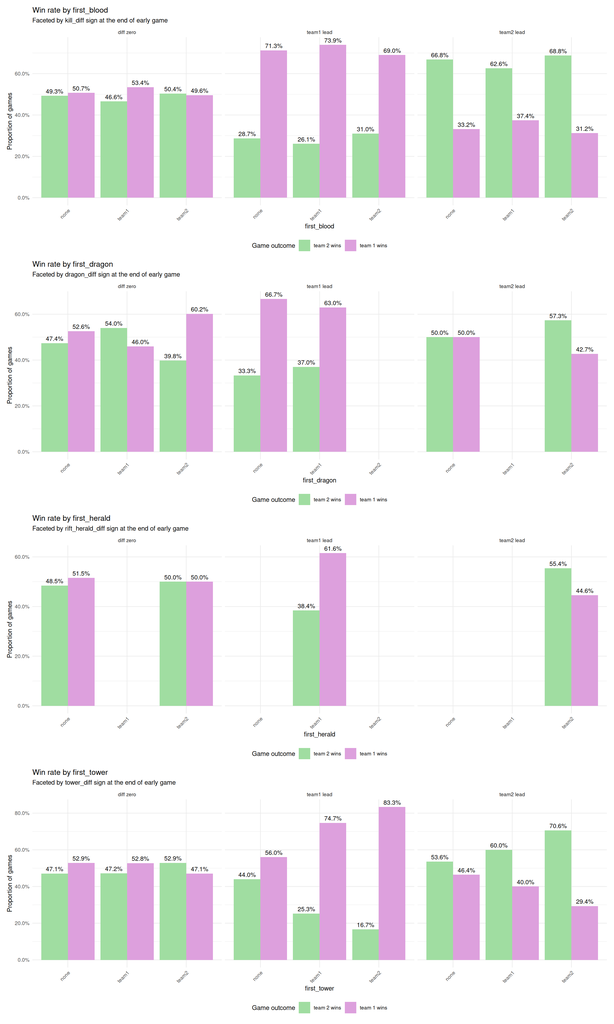

```r
direct_rels %>%
    imap(~ {
        first_col_sym <- sym(.y)
        diff_col_sym <- sym(.x)

        dataset %>%
            mutate(diff_sign = case_when(
                !!diff_col_sym > 0 ~ "team1 lead",
                !!diff_col_sym < 0 ~ "team2 lead",
                TRUE ~ "diff zero"
            )) %>%
            mutate(team1_won = factor(
                team1_won,
                levels = c(0, 1),
                labels = c("team 2 wins", "team 1 wins")
            )) %>%
            count(!!first_col_sym, diff_sign, team1_won, name = "n") %>%
            group_by(!!first_col_sym, diff_sign) %>%
            mutate(prop = n / sum(n)) %>%
            ungroup() %>%
            ggplot(aes(x = !!first_col_sym, y = prop, fill = team1_won)) +
            geom_col(position = position_dodge(preserve = "single")) +
            geom_text(
                aes(label = percent(prop, accuracy = .1)),
                position = position_dodge(width = 0.9),
                vjust = -0.5,
                size = 3) +
            facet_wrap(~diff_sign) +
            scale_y_continuous(labels = percent_format(accuracy = .1)) +
            scale_fill_manual(values = c("team 1 wins" = color1, "team 2 wins" = color2)) +
            labs(
                title = paste("Win rate by", .y),
                subtitle = paste("Faceted by", .x, "sign at the end of early game"),
                x = .y,
                y = "Proportion of games",
                fill = "Game outcome") +
            theme_minimal(base_size = 9) + # Adjust base size if needed
            theme(legend.position = "bottom", axis.text.x = element_text(angle = 45, hjust = 1))
    }) %>%
    wrap_plots(ncol = 1)
```

All of the pairs show that achieving a `first_` event doesn’t provide an advantage big enough to negate that the team is behind in corresponding `_diff`.

If team 1 has kill lead at the end of an early game, then achieving `first_blood` only gave them around 5% more win rate, same goes for team 2. Dragon and herald graphs don’t have all the cases covered, since these are low range values, there aren’t as many drake and herald kills in the early game as compared to kills. The tower diff and `first_tower` have some of the strongest win rate indicators, but tower kills are rare, only happening in less than 20% of games.

### Findings

[output not shown]

Based on these EDA findings, as our first model, we choose simple decision trees. This model choice is supported by the EDA which identified some non-linear relationships (e.g., the threshold effect of securing `first_` objectives) and mixed data types (numeric `_diff`, `_champdiff`, `time_first_*`; categorical `first_*`). While features like `time_first_*` and `_champdiff` showed limited individual predictive power, tree based methods can potentially capture any complex interactions if present and inherently perform feature selection.